# Differences in the Cancer Mutational Landscape

Chris Holt

3/May/2019

# Aim

The central dogma of cancer is that loss of normal structure leads to loss of normal function and uncontrolled cellular proliferation. There is a cyclic cycle of increased cellular proliferation leading to an increase in cellular mutations and the increase in cellular mutations can lead to an increase in cellular proliferation. This results in damage to the body and tumour growth that we know as cancer. The mutational landscape refers to different populations having a different distribution of mutation types such was what types of mutations are common, which genes are mutated, the types of nucleotide mutations etcetera. We can already see sex differences in cancer epidemiology, such as the mortality rate of certain cancers and the outcome of certain drug regimens (2). Sex differences have also been observed at the molecular level. In metastatic melanoma, it was found that males had a statistically higher burden of missense mutations(4). This paper found that, as bladder cancer mutations are most common in histone demethylases such as KDM6A, which is located on the X chromosome, females with bladder cancer have a higher number of KDM6A mutations, and thus a more aggressive tumour (3). The aim of the project is to analyse the mutational landscape and determine if there are sex-derived differences that could affect the mutational landscape.

# Question

How does the mutational landscape differ between males and females in the 33 publically available datasets from The Cancer Genome Atlas (TCGA)?

# Scope

This dataset contains clinical and mutational data, curated by TCGA, from cancer patients in the United States

# Methods

Mutational and Clinical Data will be downloaded from [The Cancer Genome Atlas](https://portal.gdc.cancer.gov/) via an R package called TCGAbiolinks(1). TCGAbiolinks will download the maf.gz files as data objects in R and I will write them out as tsv files for future use. I will be utilising the [SomaticSniper](https://www.ncbi.nlm.nih.gov/pmc/articles/PMC3268238/) pipeline. Statistcally analyses were performed using the wilcoxon rank sum test and an alpha value of less than 0.05. This analysis will look at differences in the mutation types, nucleotide changes, transitions vs transversions, chromosmal location of mutations, and gene significance.

# Results

| cohort | Full_Name |
| --- | --- |
| ACC | Adrenocortical carcinoma |
| BLCA | Bladder Urothelial Carcinoma |
| BRCA | Breast invasive carcinoma |
| CESC | Cervical squamous cell carcinoma and endocervical adenocarcinoma |
| CHOL | Cholangiocarcinoma |
| COAD | Colon adenocarcinoma |
| DLBC | Lymphoid Neoplasm Diffuse Large B-cell Lymphoma |
| ESCA | Esophageal carcinoma |
| GBM | Glioblastoma multiforme |
| HNSC | Head and Neck squamous cell carcinoma |

**Sample of the cancer cohorts and their full names**

### Proportion of sex in each cancer

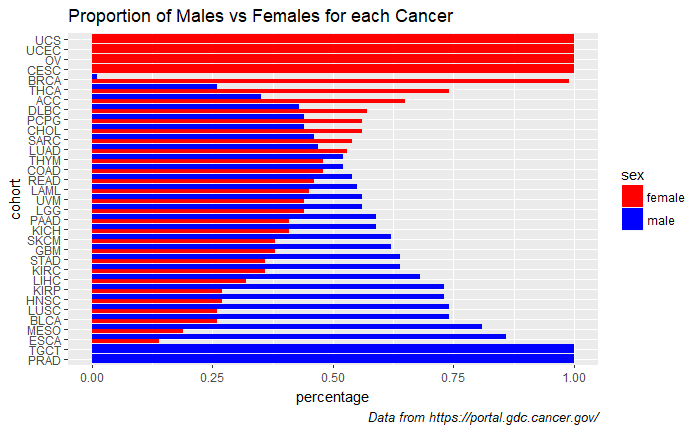

**Certain cancer cohorts are sex-biased where as others have a similar amount of males and females in the dataset. The cancers that are sex-biased (PRAD, TGCT, BRCA, CESC, OV, UCEC, UCS) were removed from this analysis.**

### Percentage of Mutation Types

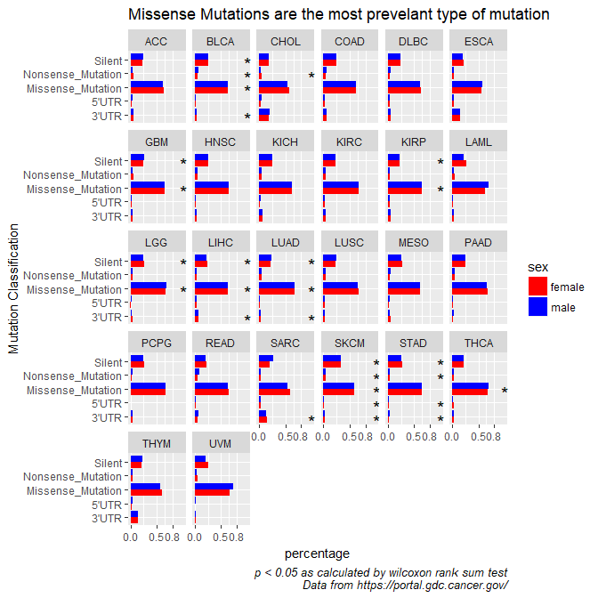

**The majority of mutation types in all the cohorts were missense mutations.**

### Proportion of Nucleotide Changes

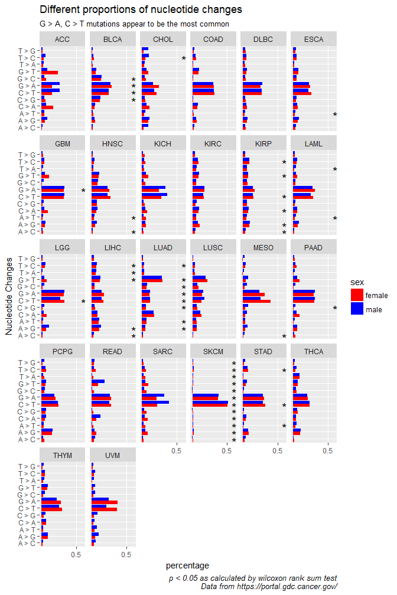

**The majority of nucleotide changes in most cancers were G > A (Ti) and C > T (Ti). Nucleotide mutations in SKCM were almost entirely composed of these two nucleotide changes. In LAML, females had a higher proportion of G > A and C > T mutations than males, whereas in SARC, males had a higher proportion**

### Proportion of Transitions and Transversions

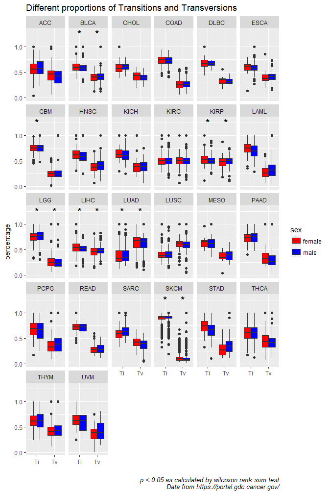

**Transitions are the majority of mutation types in both males and females across cohorts. In a couple of cohorts, transversions were more common.**

### Chromosomal Location

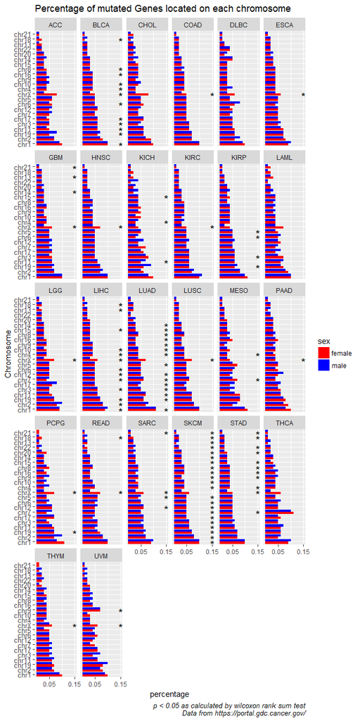

**The majority of mutations occur on chromosome 1. However, in certain cancers (for example KICH), females had more mutations on chromosome 7 where as males had more mutations on chromosome 19 (second to the proportionof mutations on chromosome 1)**

### Gene Significance across Cancers

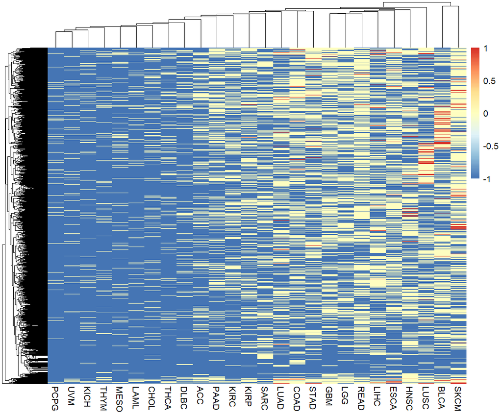

-1 means that the gene is not found in that cohort  
0 means that the gene is found in the cohort, but that it is not statistically significant  
1 means that the gene is found in the cohort and that it is statistcally significant

**The cancers on the left side of the heat map appeared to suffer mutations in a very select subset of genes, whereas a lot more genes are associated with cancers on the right. By the location of the red bars, their appears to be few sites of overlap between genes that were signifciantly mutated in any cohort.**

# Main Conclusions

There are genomic differences in the mutational landscape between males and females across the cancer datasets. Looking at Lung adenocarcinoma (LUAD), the dataset contains more females than males(0.47, 0.53). The difference in 3’UTR, Missense_Mutation, Silent mutations between males and females was found to be statistically significant (p = 0.011, 0.003, 0.001). Differences in certain nucleotide changes was found to be significant. The differences between A > G, A > T, C > G, C > T, G > A, G > C, G > T, T > C were found to be statistically significant (p = 0.027, 0.009, 0.021, 0.001, 0, 0.028, 0.008, 0.002). Females had more transitions than males (M = 0.393, 0.388) while females had less transversions than males (M = 0.617, 0.621). The differences in transitions and tranversions between males and females were found to be statistically significant in LUAD (p = 0, 0.006). Transitions are defined as a mutation that converts a purine to purine (or pyrimidine to pyrimidine). Transversions are defined as mutation that converts a purine to pyrimidine or vice versa (Ti = G > A, A > G, C > T, T > C, Tv = T > G, A > T, G > C, A > C, C > G, G > T, T > A, C > A). However, the general overall pattern of the landscape appears to be the same. Males and females have similar proportions of mutation types, more transitions than transversion, and the majority of mutations occur on chromosome 1 in similar propotions.

Looking at Gene Significance across Cancers, ten of the cancer cohorts have mutations in very few of the 21062 unique genes found in the dataset. Also looking at the graph, there is not much overlap between cancers of genes that are found to be statistically significant between males and females.

While this analysis lays the groundwork for analysing the mutational landscapes, more work has to be done to with regards to correcting the *p* value (FDR, Bonferroni etcetera), as well as looking into the effects of other factors such as smoking, exposure to chemicals, diet, age, and family history. Another area of exploration is why were the majority of nucleotide changes, across cohorts G > A and C > T mutations?

# References

### Methods

1. Colaprico A, Silva TC, Olsen C, Garofano L, Cava C, Garolini D, Sabedot T, Malta TM, Pagnotta SM, Castiglioni I, Ceccarelli M, Bontempi G, Noushmehr H (2015). “ TCGAbiolinks: An R/Bioconductor package for integrative analysis of TCGA data.” Nucleic Acids Research. doi: 10.1093/nar/gkv1507, http://doi.org/10.1093/nar/gkv1507

### Aim

2. Kim, Hae-In, et al. “Sex Differences in Cancer: Epidemiology, Genetics and Therapy.” Biomolecules & Therapeutics, The Korean Society of Applied Pharmacology, July 2018, www.ncbi.nlm.nih.gov/pmc/articles/PMC6029678/  
3. Messing, Edward M. “Molecular Landscape of Non-Muscle Invasive Bladder Cancer.” Bladder Cancer, vol. 4, no. 1, 2018, pp. 131–132., [doi:10.3233/blc-189027](https://www.ncbi.nlm.nih.gov/pubmed/29136502)  
4. Gupta, Sameer, et al. “Gender Disparity and Mutation Burden in Metastatic Melanoma.” Journal of the National Cancer Institute, Oxford University Press, 20 Aug. 2015, https://www.ncbi.nlm.nih.gov/pubmed/26296643